# Active Learning for Image Classification

# Classifying wood knots

```r
### Libraries ###
library(dplyr)
library(tidyr)
library(ggplot2)
library(reticulate)
library(pROC)

### Meta-hyperparameters ###
set.seed(3)  ###

L1_PENALTY <- 1e-2
L2_PENALTY <- 1e-2

INITIAL_EXAMPLES_PER_CLASS <- 6  # cases from the labelled dataset used to train the initial model
ADDITIONAL_CASES_TO_LABEL <- 12  # cases to label per iteration
NUM_ITERATIONS <- 50
MONTE_CARLO_SAMPLES <- 100

# This order determines the order of factor levels
KNOT_CLASSES <- c("sound_knot", "dry_knot", "encased_knot")

LABELLED_FEATURIZED_DATA <- "data/labelled_knots_featurized_resnet18.Rds"
UNLABELLED_FEATURIZED_DATA <- "data/unlabelled_knots_featurized_large_resnet18.Rds"

unlabelled_knot_data_df <- readRDS(UNLABELLED_FEATURIZED_DATA)
labelled_knot_data_df <- readRDS(LABELLED_FEATURIZED_DATA)

# We'll pretend these come from our labellers
PSEUDOLABELS_FILE <- "data/unlabelled_knot_info_area_small.csv"

inputs <- grep("^Feature", names(labelled_knot_data_df), value=TRUE)
FORM <- formula(paste0('~', paste(inputs, collapse=" + "), " - 1"))
# outcome <- "knot_class"
# FORM <- formula(paste0(outcome, '~', paste(inputs, collapse=" + "), " - 1"))
```

### Split labelled data into training and test sets

```r
class_samples <- lapply(KNOT_CLASSES, function(kc) sample(which(labelled_knot_data_df$knot_class == kc), INITIAL_EXAMPLES_PER_CLASS))

in_training_set <- (1:nrow(labelled_knot_data_df) %in% unlist(class_samples))

initial_training_set <- labelled_knot_data_df[in_training_set,]
TEST_SET <- labelled_knot_data_df[!in_training_set,]

table(initial_training_set$knot_class)
```

```
##
##   sound_knot     dry_knot encased_knot
##            6            6            6
```

```r
table(TEST_SET$knot_class)
```

```
##
##   sound_knot     dry_knot encased_knot
##          173           63           23
```

```r
table(TEST_SET$knot_class)/nrow(TEST_SET)
```

```
##
##   sound_knot     dry_knot encased_knot
##   0.66795367   0.24324324   0.08880309
```

## Initial model for knot classes

First we build a model on the available training data, and test on the test data. This model will focus on classifying a knot image into three categories: “sound_knot”, “dry_knot”, and “encased_knot”. In the blog post there was also a category for “decayed_knot”, but we will consider decay a separate attribute, and not use it in this model. We will use only a small number of the available labelled cases for training, and the rest for testing. This makes a larger test set and a smaller training set than in the blog post.

### Fit model to initial training set

```r
source("woodknots_active_learning_lib.R")

pseudolabel_function <- get_pseudolabelling_function(PSEUDOLABELS_FILE, KNOT_CLASSES)

initial_model_results <- fit_and_evaluate_model(initial_training_set)
```

## Results for initial model

### ROC curves

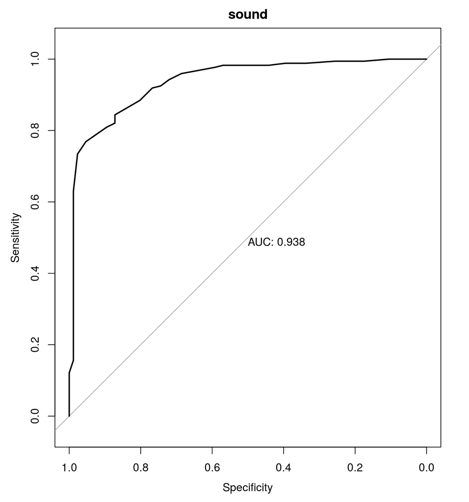

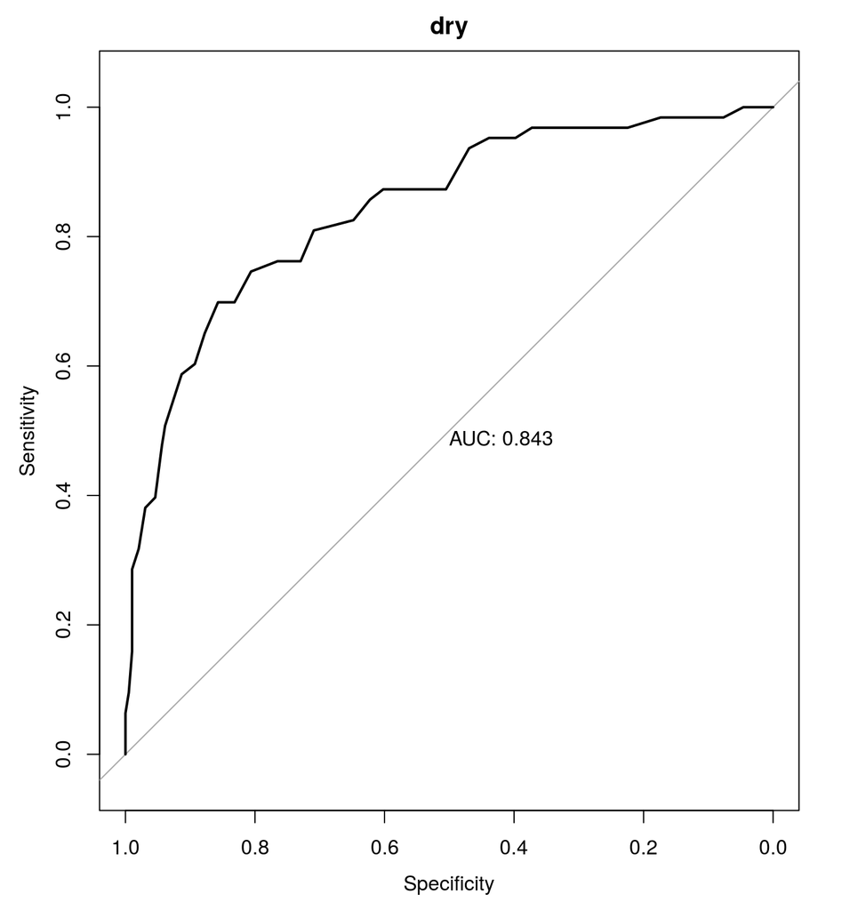

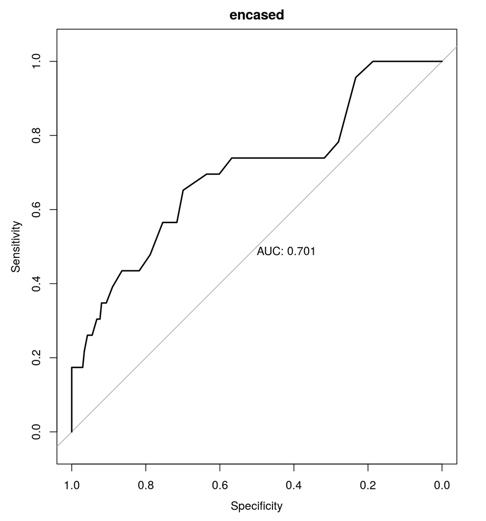

```r
mapply(plot, x=initial_model_results$roc_list, main=names(initial_model_results$roc_list), print.auc=TRUE) %>% invisible
```

#### Confusion matrix

```r
initial_model_results$confusion
```

```
##               pred_class
## knot_class     dry_knot encased_knot sound_knot
##   sound_knot         35           22        116
##   dry_knot           51           11          1
##   encased_knot       10           10          3
```

### Performance summary

```r
initial_model_results$performance
```

```
##    accuracy neg_logloss   auc_sound     auc_dry auc_encased  negentropy
##   0.6833977  -0.7914157   0.9375924   0.8434969   0.7005343  -1.5069318
```

### Histograms of class scores

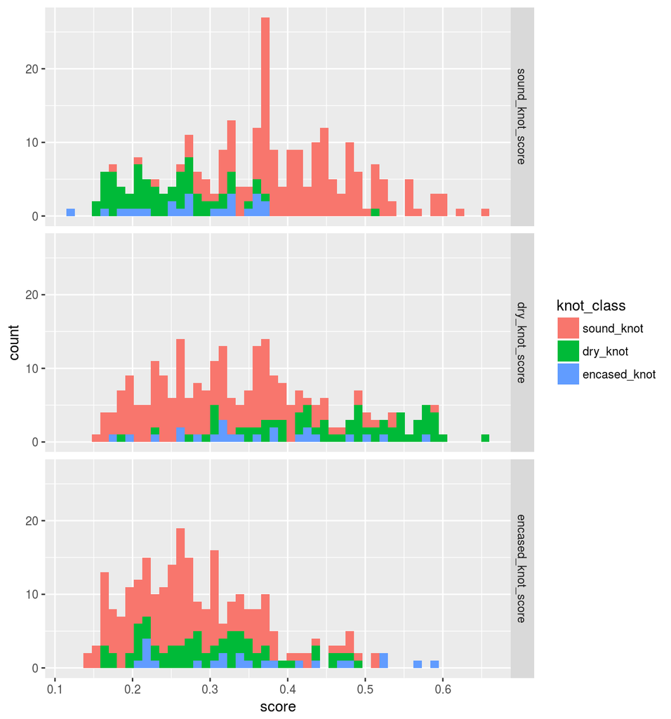

```r
plot_class_histograms(initial_model_results$test_predictions)
```

### Plot of test cases on entropy surface

Here we’ll stick to a 2D representation, where the yellow background indicates regions of lower entropy.

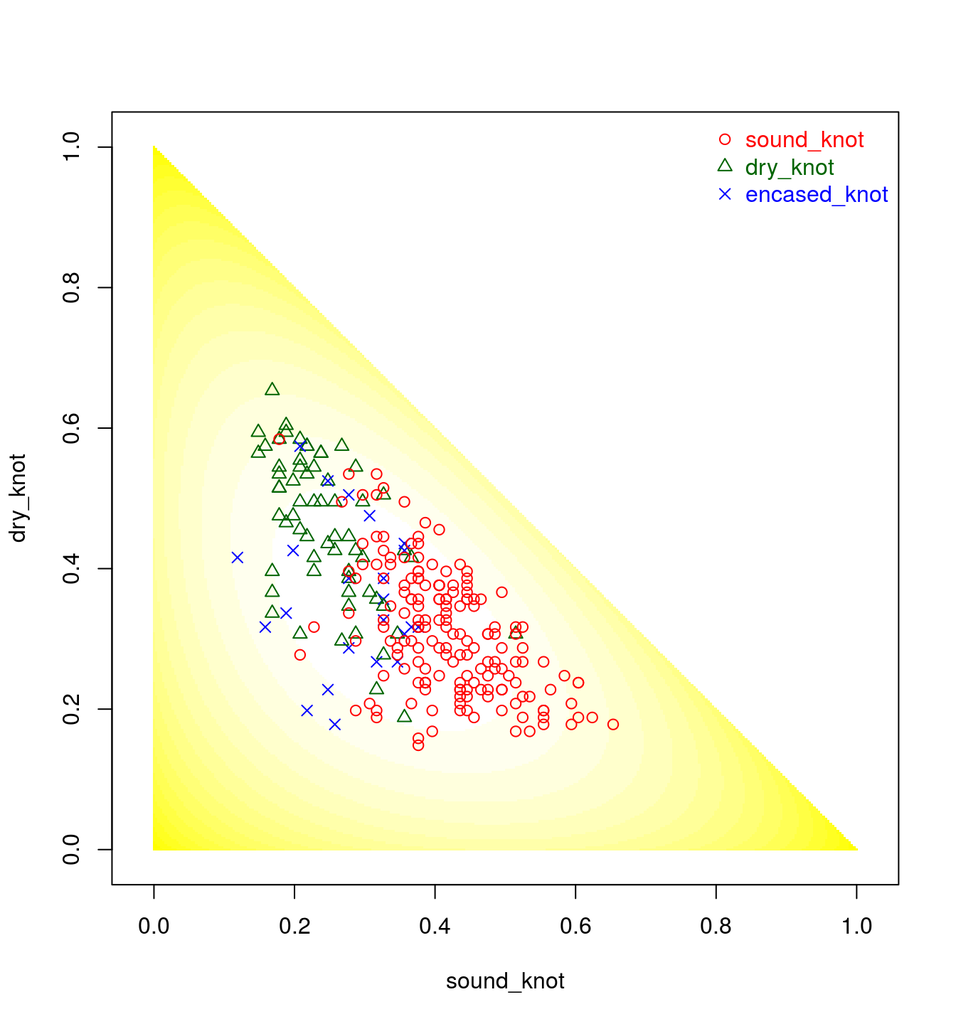

```r
plot_class_separation(initial_model_results$test_predictions)
```

## Iterate modelling, case selection, and (pseudo) labelling

These are the cases selected by the initial model for labelling:

```r
initial_model_results$selected <- select_cases(initial_model_results$model, unlabelled_knot_data_df)

initial_model_results$selected
```

```
##                path   pred_class  dry_knot encased_knot sound_knot
## 1  st1044_knot0.png     dry_knot 0.3366337    0.3366337  0.3267327
## 2  st1217_knot0.png   sound_knot 0.3267327    0.3168317  0.3564356
## 3  st1408_knot5.png   sound_knot 0.3069307    0.3366337  0.3564356
## 4  st1422_knot1.png   sound_knot 0.3069307    0.3366337  0.3564356
## 5  st1431_knot1.png   sound_knot 0.3267327    0.3168317  0.3564356
## 6  st1436_knot2.png     dry_knot 0.3465347    0.3366337  0.3168317
## 7  st1438_knot1.png encased_knot 0.3168317    0.3465347  0.3366337
## 8  st1439_knot1.png   sound_knot 0.3267327    0.3267327  0.3465347
## 9  st1537_knot1.png     dry_knot 0.3465347    0.3069307  0.3465347
## 10 st1646_knot2.png encased_knot 0.3168317    0.3465347  0.3366337
## 11 st1710_knot1.png   sound_knot 0.3366337    0.3069307  0.3564356
## 12 st1767_knot2.png     dry_knot 0.3564356    0.3267327  0.3168317
##     entropy
## 1  1.584821
## 2  1.583139
## 3  1.582260
## 4  1.582260
## 5  1.583139
## 6  1.583968
## 7  1.583968
## 8  1.584400
## 9  1.582668
## 10 1.583968
## 11 1.582260
## 12 1.583139
```

```r
new_sample <- initial_model_results$selected %>% pseudolabel_function %>% get_new_pseudolabelled_sample(unlabelled_knot_data_df)

current_training_set <- rbind(initial_training_set, new_sample[names(initial_training_set)])

ALREADY_EVALUATED <- initial_model_results$selected$path

iteration_results <- lapply(1:NUM_ITERATIONS, function(i){
  results <- fit_and_evaluate_model(current_training_set)

  candidate_cases <- unlabelled_knot_data_df[(unlabelled_knot_data_df$path %in% setdiff(unlabelled_knot_data_df$path, ALREADY_EVALUATED)),]
  results$selected <- select_cases(results$model, candidate_cases)

  ALREADY_EVALUATED <<- c(ALREADY_EVALUATED, results$selected$path)
  results$selected_labelled <- results$selected %>% pseudolabel_function
  next_sample <- results$selected %>% pseudolabel_function %>% get_new_pseudolabelled_sample(unlabelled_knot_data_df)

  current_training_set <<- rbind(current_training_set, next_sample[names(current_training_set)])

  results
})
```

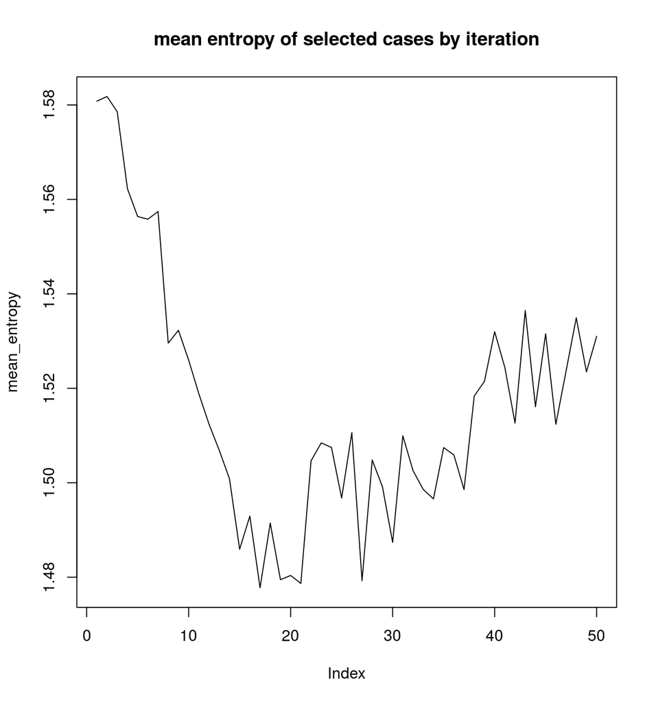

```r
mean_entropy <- sapply(iteration_results, function(ires) mean(ires$selected$entropy))
plot(mean_entropy, type='l', main="mean entropy of selected cases by iteration")
```

```r
# lapply(iteration_results, function(ires) ires$selected_labelled)
```

This shows the change in the metrics, with each row showing an iteration. The ‘negentropy’ metric is the negative entropy across all three class probabilities.

```r
do.call("rbind", lapply(iteration_results, function(ires) ires$performance))
```

```
##        accuracy neg_logloss auc_sound   auc_dry auc_encased negentropy
##  [1,] 0.6795367  -0.7765245 0.9017677 0.7836492   0.6887436  -1.492085
##  [2,] 0.7374517  -0.7694104 0.9100686 0.8633787   0.6336588  -1.493660
##  [3,] 0.7722008  -0.7371731 0.9185374 0.8525267   0.6659912  -1.465135
##  [4,] 0.7567568  -0.6828228 0.9024062 0.7981859   0.7006264  -1.420858
##  [5,] 0.6872587  -0.7266209 0.8571717 0.8284742   0.5934046  -1.449433
##  [6,] 0.7065637  -0.7086639 0.9093964 0.8343052   0.6564112  -1.422885
##  [7,] 0.7683398  -0.7151355 0.9284178 0.8424846   0.6064849  -1.430405
##  [8,] 0.7374517  -0.7110328 0.9142358 0.8172174   0.6357775  -1.427119
##  [9,] 0.7027027  -0.7173294 0.8808980 0.8122773   0.5204495  -1.435003
## [10,] 0.7451737  -0.7112642 0.8469552 0.8423226   0.5825350  -1.424416
## [11,] 0.7104247  -0.7003072 0.8642963 0.7868481   0.5974576  -1.418275
## [12,] 0.7220077  -0.6943630 0.8317650 0.8117914   0.6105380  -1.403570
## [13,] 0.7181467  -0.6837951 0.7990993 0.7422255   0.6530951  -1.401830
## [14,] 0.6949807  -0.6644110 0.7947977 0.7377713   0.7026529  -1.378116
```

[output cut: 36 more lines]

Here we plot a series of ROC curves showing how performance changes with iterations of active learning.

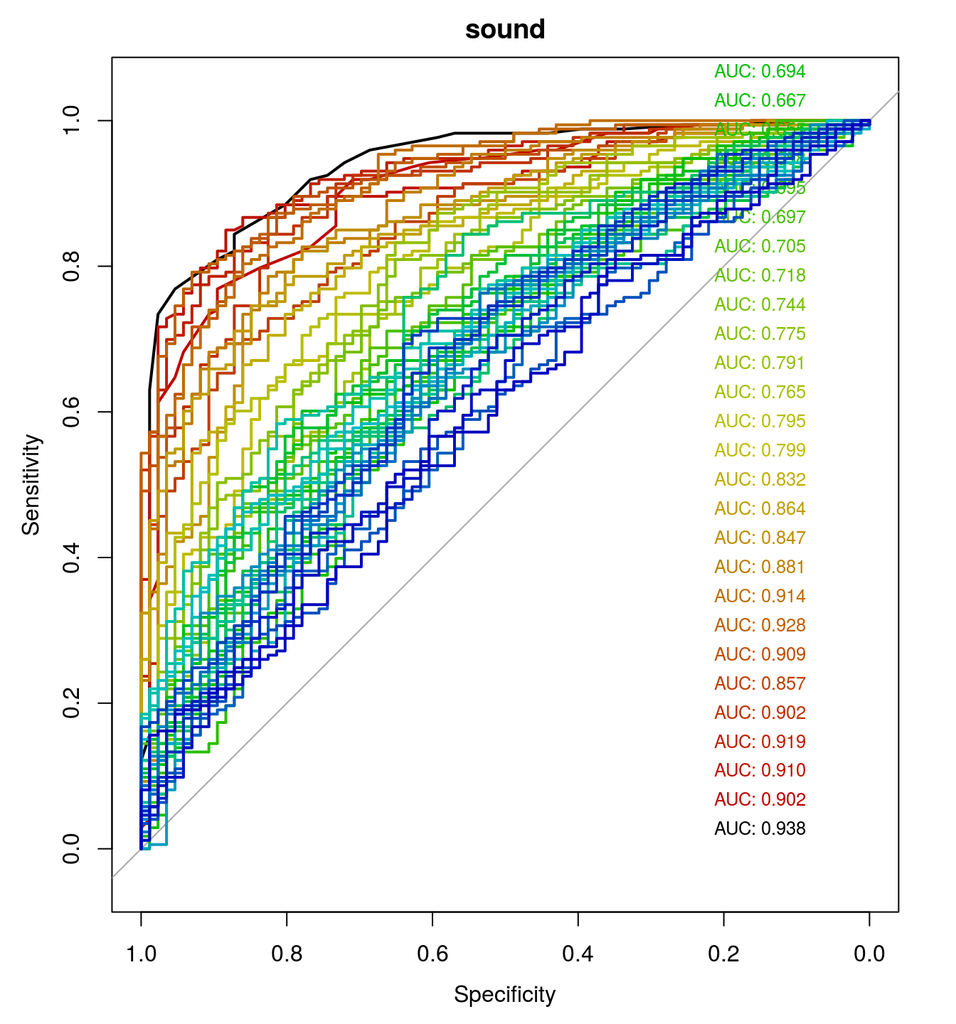

```r
plot_roc_history("sound", initial_model_results, iteration_results)
```

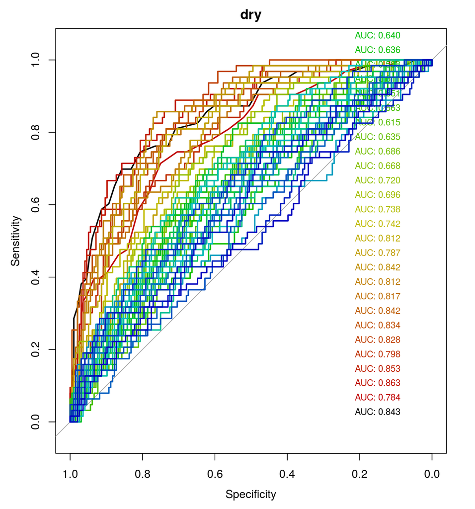

```r
plot_roc_history("dry", initial_model_results, iteration_results)
```

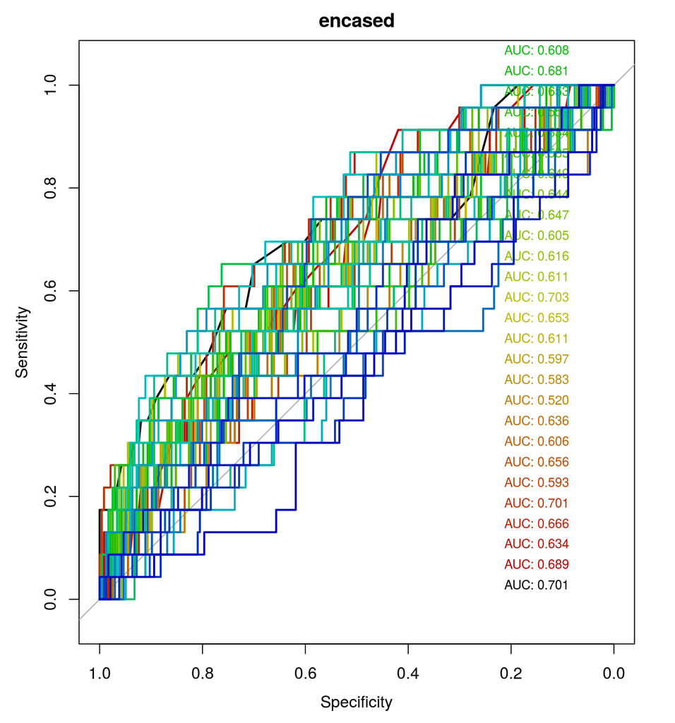

```r
plot_roc_history("encased", initial_model_results, iteration_results)
```

### Final model results

```r
final_model_results <- iteration_results[[NUM_ITERATIONS]]
```

### Confusion Matrix

```r
final_model_results$confusion
```

```
##               pred_class
## knot_class     dry_knot encased_knot sound_knot
##   sound_knot         12            1        160
##   dry_knot            9            0         54
##   encased_knot        6            0         17
```

### Performance summary

Summary of performance using cases selected with active learning:

```r
(selected_sample_results <- final_model_results$performance)
```

```
##    accuracy neg_logloss   auc_sound     auc_dry auc_encased  negentropy
##   0.6525097  -0.6936686   0.5980643   0.5342566   0.4143331  -1.4293866
```

### Histograms of class scores for final model

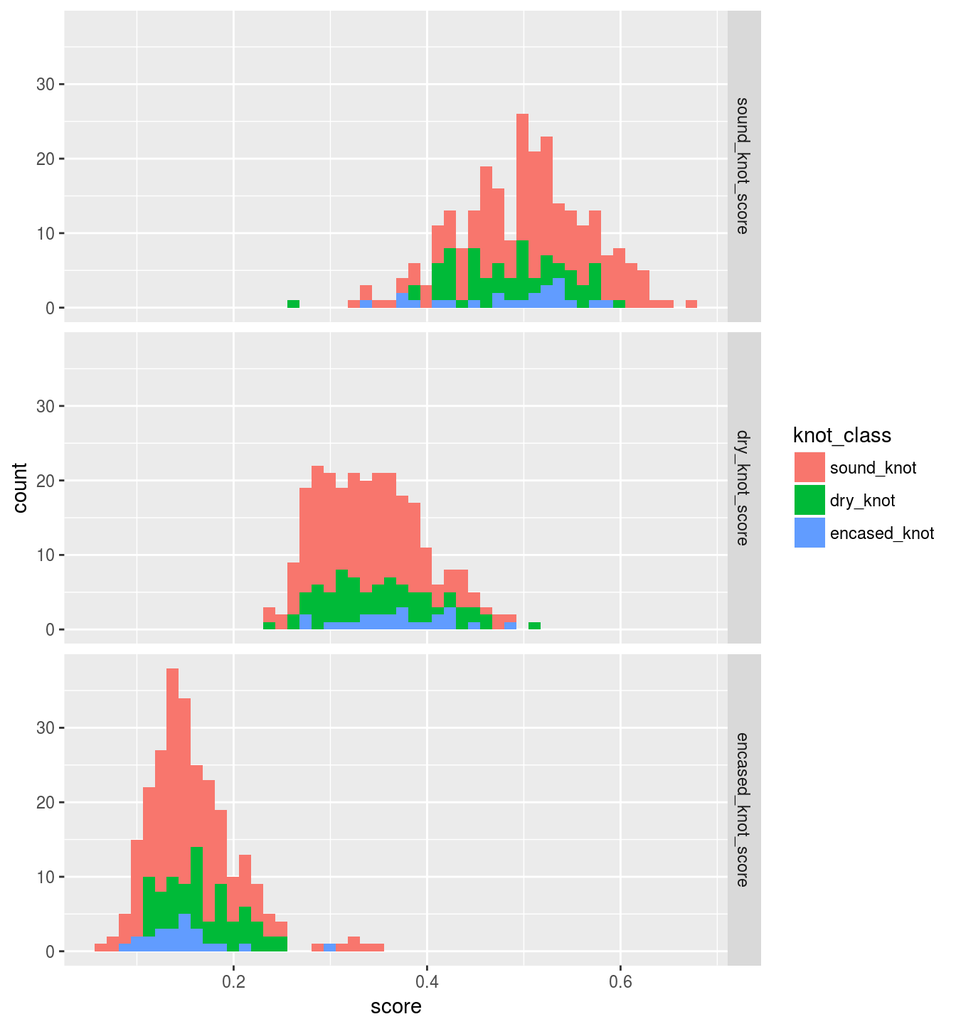

```r
plot_class_histograms(final_model_results$test_predictions)
```

### Entropy surface plot

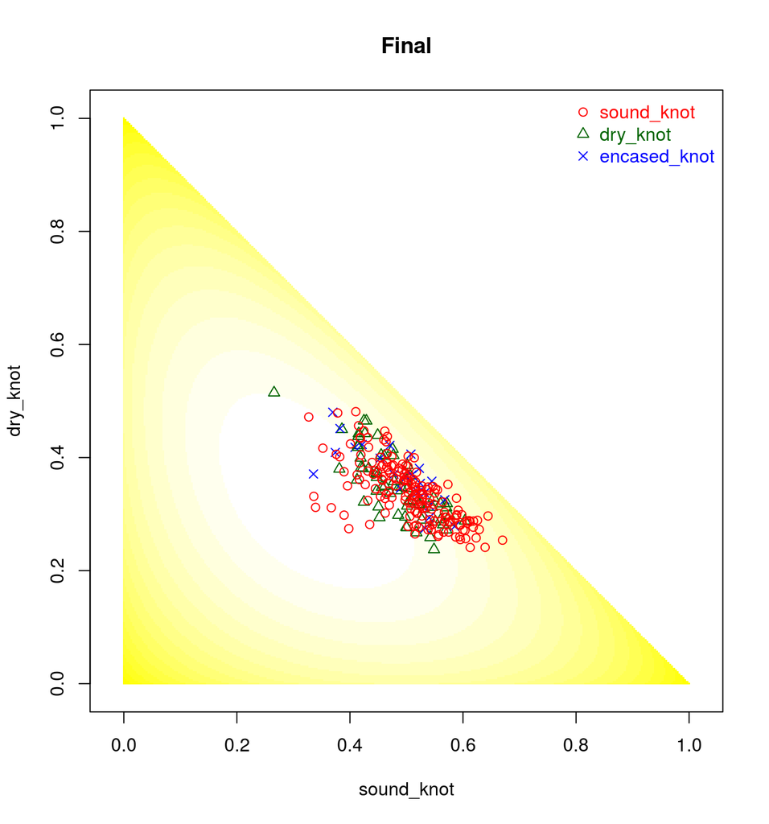

```r
plot_class_separation(final_model_results$test_predictions, main="Final")
```